# Projects - Example Project for ECON 326

econ 326

regression

projects

R

visualization

data wrangling

data cleaning

multiple regression

homoskedasticity

multicollinearity

Breusch-Pagan test

heteroskedasticity

vif

dummy variable

interaction terms

Let’s put it all together! This notebook is an example of what a “final project” might look like in ECON 326. It summarizes and uses all many of the empirical skills and R commands present in the other notebooks.

Author

COMET Team  
*Sarthak Kwatra, Charlotte White*

Published

1 July 2023

### Prerequisites

- Introduction to Data in R
- Introduction to Data Visualization - I and II
- Simple Regression
- Multiple Regression
- Issues in Regression using R
- Interactions and Non-Linear Terms in Regressions

## Introduction:

Now that you are well armored with a statistical toolkit and experience with R, you are well on your way to embark on your own economic research adventure! This project serves as a sample to give you some intuition into the broad steps to a successful research project. It synthesizes the knowledge you have gained in your study of the ECON 325 and ECON 326 modules, and allows you to apply it to your own research project. It explains the steps involved in cleaning your data and preparing it for analysis, the actual analysis itself, and the careful interpretation and visualization of that analysis.

It is important to note that while the more minute tasks in each of these big steps may vary according to the needs of the project, these steps remain mostly the same. Let’s get started by importing all of the packages that we will use through out this module!

```r
# If any of the packages happened to not be installed for you, use the command install.packages() with the name of the packages, like 'stargazer'

library(ggplot2)
library(haven)
library(stargazer)
library(tidyverse)
library(car)
library(vtable)
library(sandwich)
library(corrplot)
library(lmtest)
source("Projects_Example_Project_ECON326_tests.r")
```

## Note:

Hlavac, Marek (2022). stargazer: Well-Formatted Regression and Summary Statistics Tables. R package version 5.2.3. https://CRAN.R-project.org/package=stargazer

## Development and the Planet

Following a 2019 scientific report which revealed an alarming rate of climate change in the country, the [Government of Canada declared a national climate emergency.] (https://globalnews.ca/news/5401586/canada-national-climate-emergency/) Canada has been far from the only one to take notice and when it comes to the environment; threat of climate change continues to take priority at an international level. All over the world, people are seeking to better understand the causes and impacts of climate change, and looking for ways to mitigate and adapt to how these changes will affect our lives. In particular, the greenhouse gas carbon dioxide [$CO_2$] gets a lot of attention. While there are many other gasses that contribute to to the atmospheric greenhouse effect, [$CO_2$] is one of the most immediate concerns because of its role in industrialization and energy use.

Gross domestic product (GDP), is a measure that you’re likely very familiar with at this point. As a measure production, GDP is often used to infer the health of an economy or to some degree, the prosperity of the people operating within it. In general, a rising GDP is a desirable outcome. However, we might wonder whether all other outcomes associated with a higher GDP are desirable. In this project, we will be examining the connection between the production of [$CO_2$] and GDP in Canada.

****🔎 Let’s think critically**** > 🟠 GDP is commonly considered to *not* be a zero-sum measure, meaning that a rising GDP in one country does not mean another country’s GDP has to fall. What are the limitations on GDP growth, then? > 🟠 What are the implications of assuming that there can infinite GDP growth when it’s connected to finite measures such as the amount of [$CO_2$] that can be sustainably produced and recaptured? Is this just a reflection of what our current energy sources and technology allow, or is there more to the story in how we think about economic growth in general?

## Part 1: Preparing our Data

For the sake of our analysis today, we hope to observe whether factors like Electricity Generation, GDP, and Population, have had any impact on CO2 Emissions across all the Canadian Provinces.

### Importing Data into R

Once you have gathered data, R has great dependability and dexterity in the viewing and manipulation of that data. To do this, you will want to import your datasets into R, like you have observed in multiple other modules so far. The data that you have gathered could be in a host of different formats like,

- .csv (Comma-Separated Values file),
- .dta (STATA data file),
- .xlsx (Excel file),
- .sav (SPSS file) or,
- .sas (SAS file)

All of these files correspond to different softwares, like Microsoft Excel, STATA, or SPSS, but can nonetheless be conveniently imported onto R. Fortunately, we will not be needing separate packages to import these files; `haven` is our jack-of-all-trades. We used the command `library(haven)` to load it at beginning of this module. In this case, since all of our data is in the .csv format, we use the function `read_csv`. The corresponding functions for the other formats are, `read_dta`, `read_spss`, and so on.

```r
# Loading the Data into R

gdp_data <- read_csv("../datasets_projects/gdp_data.csv")
pollution_data <- read_csv("../datasets_projects/pollution_data.csv")
elec_data <- read_csv("../datasets_projects/elec_data.csv")
pop_data <- read_csv("../datasets_projects/pop_data.csv")
```

> NOTE: By default, some functions in the Haven package, like `read_csv()`, assume that the CSV file has a header row with variable names. If your file does not have a header, or you would like different headers for your columns, you can use the argument `col_names` to adjust the column names manually.

### Viewing the Data

Once you have imported your datasets in R, it is worthwhile to get an overview of the data. There are two main reasons for this:

- Not every dataset will come formatted in a way that is suitable for your analysis, and therefore it is important to understand the structure of your dataset and its variables
- An overview allows you to recognize any potential obvious issues that the data may have, like missing values, duplicates, or unnecessary variables, that would pose issues in your analysis at a later stage

Commands that can be used to view and understand the structure of your data include: `head()`, `str()`, `summary()`, and `view()`. These four functions can be used roughly interchangeably understand the structure of your data

```r
# Make sure to run these commands individually!

head(gdp_data)
```

```
# A tibble: 6 × 16
  REF_DATE GEO     DGUID Value North American Indus…¹ UOM   UOM_ID SCALAR_FACTOR
     <dbl> <chr>   <chr> <chr> <chr>                  <chr>  <dbl> <chr>
1     2009 Newfou… 2016… Chai… All industries [T001]  Doll…     81 millions
2     2010 Newfou… 2016… Chai… All industries [T001]  Doll…     81 millions
3     2011 Newfou… 2016… Chai… All industries [T001]  Doll…     81 millions
4     2012 Newfou… 2016… Chai… All industries [T001]  Doll…     81 millions
5     2013 Newfou… 2016… Chai… All industries [T001]  Doll…     81 millions
6     2014 Newfou… 2016… Chai… All industries [T001]  Doll…     81 millions
# ℹ abbreviated name: ¹`North American Industry Classification System (NAICS)`
# ℹ 8 more variables: SCALAR_ID <dbl>, VECTOR <chr>, COORDINATE <chr>,
#   VALUE <dbl>, STATUS <lgl>, SYMBOL <lgl>, TERMINATED <lgl>, DECIMALS <dbl>
```

```r
summary(pollution_data)
```

```
    REF_DATE        GEO               DGUID              Sector
 Min.   :2009   Length:840         Length:840         Length:840
 1st Qu.:2012   Class :character   Class :character   Class :character
 Median :2014   Mode  :character   Mode  :character   Mode  :character
 Mean   :2014
 3rd Qu.:2017
 Max.   :2020
     UOM                UOM_ID    SCALAR_FACTOR        SCALAR_ID
 Length:840         Min.   :198   Length:840         Min.   :0
 Class :character   1st Qu.:198   Class :character   1st Qu.:0
 Mode  :character   Median :198   Mode  :character   Median :0
                    Mean   :198                      Mean   :0
                    3rd Qu.:198                      3rd Qu.:0
                    Max.   :198                      Max.   :0
    VECTOR            COORDINATE         VALUE           STATUS
 Length:840         Min.   : 1.100   Min.   :-51464.0   Mode:logical
 Class :character   1st Qu.: 4.118   1st Qu.:   473.8   NA's:840
 Mode  :character   Median : 7.650   Median :  6556.0
                    Mean   : 7.630   Mean   : 62992.9
                    3rd Qu.:11.118   3rd Qu.: 63519.5
                    Max.   :14.200   Max.   :788071.0
  SYMBOL        TERMINATED        DECIMALS
 Mode:logical   Mode:logical   Min.   :0
 NA's:840       NA's:840       1st Qu.:0
                               Median :0
                               Mean   :0
                               3rd Qu.:0
                               Max.   :0
```

```r
str(elec_data)
```

```
spc_tbl_ [13,744 × 16] (S3: spec_tbl_df/tbl_df/tbl/data.frame)
 $ REF_DATE                      : chr [1:13744] "2009-01" "2009-02" "2009-03" "2009-04" ...
 $ GEO                           : chr [1:13744] "Newfoundland and Labrador" "Newfoundland and Labrador" "Newfoundland and Labrador" "Newfoundland and Labrador" ...
 $ DGUID                         : chr [1:13744] "2016A000210" "2016A000210" "2016A000210" "2016A000210" ...
 $ Class of electricity producer : chr [1:13744] "Total all classes of electricity producer" "Total all classes of electricity producer" "Total all classes of electricity producer" "Total all classes of electricity producer" ...
 $ Type of electricity generation: chr [1:13744] "Total all types of electricity generation" "Total all types of electricity generation" "Total all types of electricity generation" "Total all types of electricity generation" ...
 $ UOM                           : chr [1:13744] "Megawatt hours" "Megawatt hours" "Megawatt hours" "Megawatt hours" ...
 $ UOM_ID                        : num [1:13744] 210 210 210 210 210 210 210 210 210 210 ...
 $ SCALAR_FACTOR                 : chr [1:13744] "units" "units" "units" "units" ...
 $ SCALAR_ID                     : num [1:13744] 0 0 0 0 0 0 0 0 0 0 ...
 $ VECTOR                        : chr [1:13744] "v44174695" "v44174695" "v44174695" "v44174695" ...
 $ COORDINATE                    : chr [1:13744] "2.1.1" "2.1.1" "2.1.1" "2.1.1" ...
 $ VALUE                         : num [1:13744] 4174723 3706629 4082102 3268823 2754027 ...
 $ STATUS                        : chr [1:13744] NA NA NA NA ...
 $ SYMBOL                        : chr [1:13744] NA NA NA NA ...
 $ TERMINATED                    : logi [1:13744] NA NA NA NA NA NA ...
 $ DECIMALS                      : num [1:13744] 0 0 0 0 0 0 0 0 0 0 ...
 - attr(*, "spec")=
  .. cols(
  ..   REF_DATE = col_character(),
  ..   GEO = col_character(),
  ..   DGUID = col_character(),
  ..   `Class of electricity producer` = col_character(),
  ..   `Type of electricity generation` = col_character(),
  ..   UOM = col_character(),
  ..   UOM_ID = col_double(),
  ..   SCALAR_FACTOR = col_character(),
  ..   SCALAR_ID = col_double(),
  ..   VECTOR = col_character(),
  ..   COORDINATE = col_character(),
  ..   VALUE = col_double(),
  ..   STATUS = col_character(),
  ..   SYMBOL = col_character(),
  ..   TERMINATED = col_logical(),
  ..   DECIMALS = col_double()
  .. )
 - attr(*, "problems")=<externalptr>
```

```r
view(pop_data)
```

An overview of our data reveals a few interesting things. All of data has been collected for the years 2009 - 2020. However, while the GDP and CO2 Emissions data is Annual, the Electricity Generation Data is Monthly, and the Population Data is Quarterly. It is also interesting to note that the some of the values for Electricity Generation are missing for some years for the Provinces of Newfoundland and Labrador, and Prince Edward Island.

### Cleaning the Data

Having recognized these potential issues, getting rid of them is important, and it deems the name “Cleaning the Data” to this section of the project. An important rough structure to keep in mind while cleaning your data is called “Tidy Data”, introduced by the statistician Hadley Wickham, where,

- Each Variable has its own Column
- Each Observation has its own Row, and,
- Each Value has its own Cell

To begin with, we try to keep the column names of our variables such that they are short and easy to manipulate, so let’s change some of the column names in our datasets.

```r
# Changing the Names across our Datasets

pollution_data <- pollution_data %>% rename(c(year = REF_DATE, province = GEO, sector = Sector, CO2 = VALUE))

gdp_data <- gdp_data %>% rename(c(year = REF_DATE, province = GEO, NAICS = `North American Industry Classification System (NAICS)`, GDP = VALUE))

elec_data <- elec_data %>% rename(c(year = REF_DATE, province = GEO, type = `Type of electricity generation`, elec = VALUE))

pop_data <- pop_data %>% rename(c(year = REF_DATE, province = GEO, pop = VALUE))
```

Next, note that across our Pollution and Population datasets, there are aggregations to a Canada-wide level, while our analysis is limited to the Provinces. Therefore, an inclusion of the Canada-wide aggregations will lead to a bias in our results. Let’s get rid of that by filtering them out.

```r
# Filtering to keep every observation for which the GEO isn't equal to Canada

pop_data <- pop_data %>% filter(province != 'Canada')
pollution_data <- pollution_data %>% filter(province != 'Canada')
```

As noted before, there were some missing values in the Electricity Generation dataset. Although there are multiple ways of dealing with missing data, like using averages, or using advanced imputation techniques like multiple imputation, we choose to deal with missing values here by omitting them from our data.

```r
elec_data <- elec_data %>% filter(elec != is.na(elec))
```

Similar aggregations also exist in the Pollution dataset for “Total, industries and households”, “Total, industries”, and “Total, households”. They also exist in the Electricity Generation dataset as “Total all types of electricity generation”. Let’s filter them, only this time, we will keep the aggregates across the categories of electricity generation and pollution, and get rid of the sub-categories.

```r
pollution_data <- pollution_data %>% filter(sector == "Total, industries and households")
elec_data <- elec_data %>% filter(type == 'Total all types of electricity generation')
```

Next, as we previously noted, while the GDP and CO2 Emissions data is Annual, the Electricity Generation Data is Monthly, and the Population Data is Quarterly. Therefore, let’s group them both to Yearly levels. Before we do that, note that “REF_DATE” contains the variables **Month** and **Year**. Therefore, satisfying our principles Tidy Data, let’s use the Substring function to break it down into Month and Year.

```r
elec_data <- elec_data %>%
  mutate(year = substr(year, 1, 4), month = substr(year, 6, 7))

pop_data <- pop_data %>%
  mutate(year = substr(year, 1, 4), month = substr(year, 6, 7))
```

Now, let’s work on making both the Electricity and Population datasets annual.

```r
elec_data_grouped <- elec_data %>%
  group_by(year, province) %>%
  summarise(electricity = round(mean(elec)))
```

```
`summarise()` has regrouped the output.
ℹ Summaries were computed grouped by year and province.
ℹ Output is grouped by year.
ℹ Use `summarise(.groups = "drop_last")` to silence this message.
ℹ Use `summarise(.by = c(year, province))` for per-operation grouping
  (`?dplyr::dplyr_by`) instead.
```

```r
pop_data_grouped <- pop_data %>%
  group_by(year, province) %>%
  summarise(population = round(mean(pop)))
```

```
`summarise()` has regrouped the output.
ℹ Summaries were computed grouped by year and province.
ℹ Output is grouped by year.
ℹ Use `summarise(.groups = "drop_last")` to silence this message.
ℹ Use `summarise(.by = c(year, province))` for per-operation grouping
  (`?dplyr::dplyr_by`) instead.
```

Our next step will be to merge our datasets, so that we can smoothly run the analysis from one clean reference.

```r
# Making the Data types compatible for joining
pop_data_grouped <- pop_data_grouped %>% mutate(year = as.double(year))
elec_data_grouped <- elec_data_grouped %>% mutate(year = as.double(year))

# Merging the four datasets into two
merged_data_1 <- left_join(gdp_data, pop_data_grouped, by = c('year', 'province'))
merged_data_2 <- left_join(pollution_data, elec_data_grouped, by = c('year', 'province'))

# Performing the Final Merge
merged_data <- left_join(merged_data_1, merged_data_2, by = c('year', 'province'))
```

```r
str(merged_data)
```

```
spc_tbl_ [156 × 31] (S3: spec_tbl_df/tbl_df/tbl/data.frame)
 $ year           : num [1:156] 2009 2010 2011 2012 2013 ...
 $ province       : chr [1:156] "Newfoundland and Labrador" "Newfoundland and Labrador" "Newfoundland and Labrador" "Newfoundland and Labrador" ...
 $ DGUID.x        : chr [1:156] "2016A000210" "2016A000210" "2016A000210" "2016A000210" ...
 $ Value          : chr [1:156] "Chained (2012) dollars" "Chained (2012) dollars" "Chained (2012) dollars" "Chained (2012) dollars" ...
 $ NAICS          : chr [1:156] "All industries [T001]" "All industries [T001]" "All industries [T001]" "All industries [T001]" ...
 $ UOM.x          : chr [1:156] "Dollars" "Dollars" "Dollars" "Dollars" ...
 $ UOM_ID.x       : num [1:156] 81 81 81 81 81 81 81 81 81 81 ...
 $ SCALAR_FACTOR.x: chr [1:156] "millions" "millions" "millions" "millions" ...
 $ SCALAR_ID.x    : num [1:156] 6 6 6 6 6 6 6 6 6 6 ...
 $ VECTOR.x       : chr [1:156] "v62464519" "v62464519" "v62464519" "v62464519" ...
 $ COORDINATE.x   : chr [1:156] "1.2.1" "1.2.1" "1.2.1" "1.2.1" ...
 $ GDP            : num [1:156] 28944 30474 31376 29977 31486 ...
 $ STATUS.x       : logi [1:156] NA NA NA NA NA NA ...
 $ SYMBOL.x       : logi [1:156] NA NA NA NA NA NA ...
 $ TERMINATED.x   : logi [1:156] NA NA NA NA NA NA ...
 $ DECIMALS.x     : num [1:156] 1 1 1 1 1 1 1 1 1 1 ...
 $ population     : num [1:156] 516170 521590 524725 526349 527448 ...
 $ DGUID.y        : chr [1:156] "2016A000210" "2016A000210" "2016A000210" "2016A000210" ...
 $ sector         : chr [1:156] "Total, industries and households" "Total, industries and households" "Total, industries and households" "Total, industries and households" ...
 $ UOM.y          : chr [1:156] "Kilotonnes" "Kilotonnes" "Kilotonnes" "Kilotonnes" ...
 $ UOM_ID.y       : num [1:156] 198 198 198 198 198 198 198 198 198 198 ...
 $ SCALAR_FACTOR.y: chr [1:156] "units" "units" "units" "units" ...
 $ SCALAR_ID.y    : num [1:156] 0 0 0 0 0 0 0 0 0 0 ...
 $ VECTOR.y       : chr [1:156] "v1013973302" "v1013973302" "v1013973302" "v1013973302" ...
 $ COORDINATE.y   : num [1:156] 2.1 2.1 2.1 2.1 2.1 2.1 2.1 2.1 2.1 2.1 ...
 $ CO2            : num [1:156] 9324 9474 9627 9171 9260 ...
 $ STATUS.y       : logi [1:156] NA NA NA NA NA NA ...
 $ SYMBOL.y       : logi [1:156] NA NA NA NA NA NA ...
 $ TERMINATED.y   : logi [1:156] NA NA NA NA NA NA ...
 $ DECIMALS.y     : num [1:156] 0 0 0 0 0 0 0 0 0 0 ...
 $ electricity    : num [1:156] 3114893 3396756 3392520 3582204 3511897 ...
 - attr(*, "spec")=
  .. cols(
  ..   REF_DATE = col_double(),
  ..   GEO = col_character(),
  ..   DGUID = col_character(),
  ..   Value = col_character(),
  ..   `North American Industry Classification System (NAICS)` = col_character(),
  ..   UOM = col_character(),
  ..   UOM_ID = col_double(),
  ..   SCALAR_FACTOR = col_character(),
  ..   SCALAR_ID = col_double(),
  ..   VECTOR = col_character(),
  ..   COORDINATE = col_character(),
  ..   VALUE = col_double(),
  ..   STATUS = col_logical(),
  ..   SYMBOL = col_logical(),
  ..   TERMINATED = col_logical(),
  ..   DECIMALS = col_double()
  .. )
 - attr(*, "problems")=<externalptr>
```

```r
#renaming some categories
merged_data <- merged_data  %>%
  rename(gdp = GDP)

# Now we need some factors. `Province` should be a factor variable.

merged_data  <- merged_data  %>%
  mutate(province = case_when(
    province == "Newfoundland and Labrador" ~ "1",
    province == "Prince Edward Island" ~ "2",
    province == "Nova Scotia" ~ "3",
    province == "New Brunswick" ~ "4",
    province == "Quebec" ~ "5",
    province == "Ontario" ~ "6",
    province == "Manitoba" ~ "7",
    province == "Saskatchewan" ~ "8",
    province == "Alberta" ~ "9",
    province == "British Columbia" ~ "10",
    province == "Yukon" ~ "11",
    province == "Northwest Territories" ~ "12",
    province == "Nunavut" ~ "13",
  )) %>%
  mutate(province = as_factor(province))

#Now for clarity, we'll rename the dataset.

CO2_data <- merged_data
```

Now let’s see how that’s changed our data structure.

```r
str(CO2_data)
```

```
tibble [156 × 31] (S3: tbl_df/tbl/data.frame)
 $ year           : num [1:156] 2009 2010 2011 2012 2013 ...
 $ province       : Factor w/ 13 levels "1","2","3","4",..: 1 1 1 1 1 1 1 1 1 1 ...
 $ DGUID.x        : chr [1:156] "2016A000210" "2016A000210" "2016A000210" "2016A000210" ...
 $ Value          : chr [1:156] "Chained (2012) dollars" "Chained (2012) dollars" "Chained (2012) dollars" "Chained (2012) dollars" ...
 $ NAICS          : chr [1:156] "All industries [T001]" "All industries [T001]" "All industries [T001]" "All industries [T001]" ...
 $ UOM.x          : chr [1:156] "Dollars" "Dollars" "Dollars" "Dollars" ...
 $ UOM_ID.x       : num [1:156] 81 81 81 81 81 81 81 81 81 81 ...
 $ SCALAR_FACTOR.x: chr [1:156] "millions" "millions" "millions" "millions" ...
 $ SCALAR_ID.x    : num [1:156] 6 6 6 6 6 6 6 6 6 6 ...
 $ VECTOR.x       : chr [1:156] "v62464519" "v62464519" "v62464519" "v62464519" ...
 $ COORDINATE.x   : chr [1:156] "1.2.1" "1.2.1" "1.2.1" "1.2.1" ...
 $ gdp            : num [1:156] 28944 30474 31376 29977 31486 ...
 $ STATUS.x       : logi [1:156] NA NA NA NA NA NA ...
 $ SYMBOL.x       : logi [1:156] NA NA NA NA NA NA ...
```

[output cut: 17 more lines]

Great! We’re ready to start building our model.

## Part 2: Building our Multiple Regression Model

Now that we have our dataset ready and cleaned, let’s start to think about building our model. What are the relationships that we’re interested in investigating? For the dataset that we’re working with, these would be : gross domestic product (GDP), electricity, and population.

> *Think Deeper*: Why might we suspect that relationships exist between these variables? Is this consistent with economic theory? How would these relationships relate to your own experience?

Let’s begin investigating these relationships by making some visualizations.

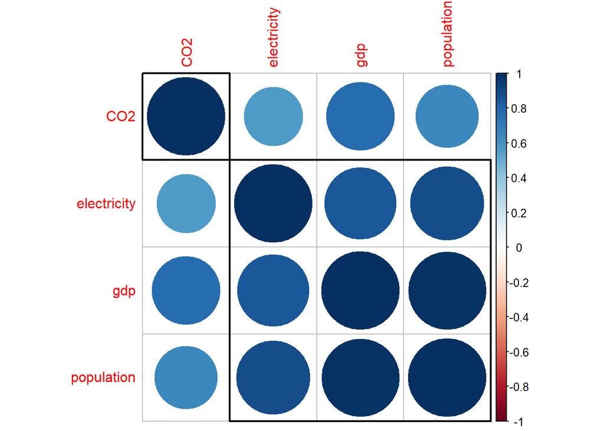

```r
corr_plot_data <- CO2_data[, c('CO2', 'gdp', 'population', 'electricity')]
corr_plot_data <- as.data.frame(corr_plot_data)

# Compute the correlation matrix)
cor_matrix = cor(corr_plot_data)

# Create the correlation plot
corrplot(cor_matrix, order = 'hclust', addrect = 2)
```

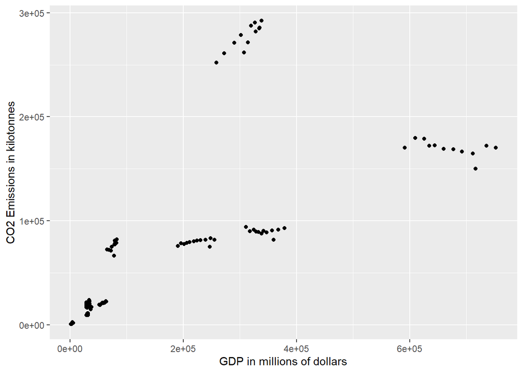

```r
a <- ggplot(data = CO2_data, aes(x = gdp, y = CO2))+
  xlab("GDP in millions of dollars")+
  ylab("CO2 Emissions in kilotonnes") + scale_x_continuous()

a + geom_point()
```

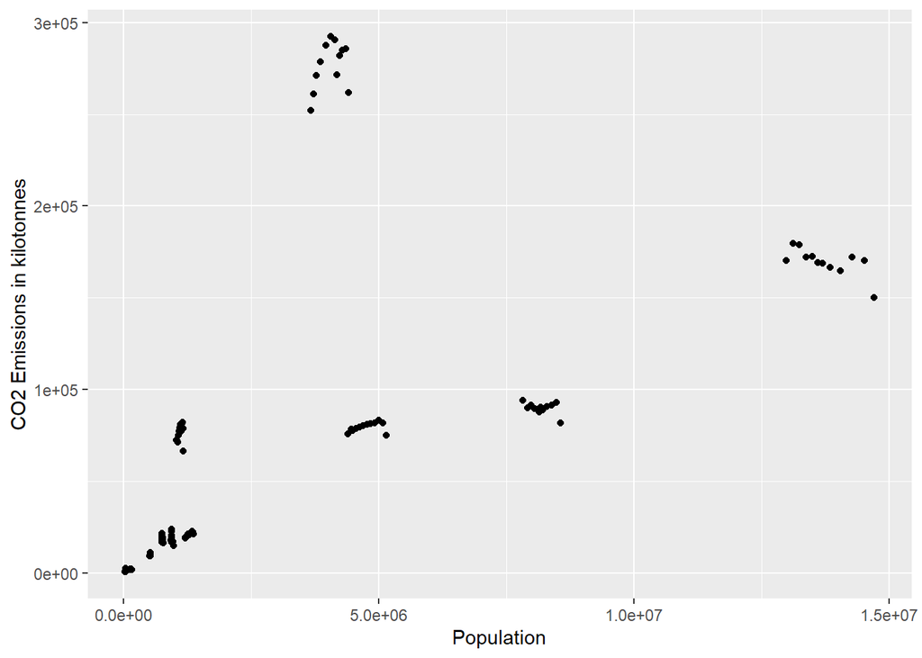

```r
b <- ggplot(data = CO2_data, aes(x = population, y = CO2))+
  xlab("Population")+
  ylab("CO2 Emissions in kilotonnes") + scale_x_continuous()

b + geom_point()
```

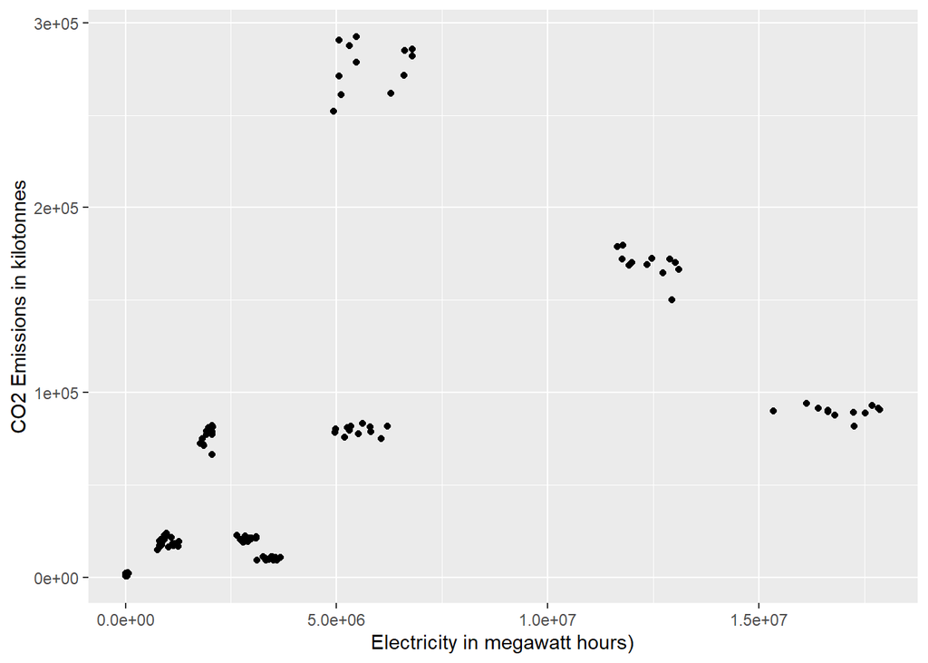

```r
c <- ggplot(data = CO2_data, aes(x = electricity, y = CO2))+
  xlab("Electricity in megawatt hours)")+
  ylab("CO2 Emissions in kilotonnes") + scale_x_continuous()

c + geom_point()
```

```r
view(gdp_data)
```

```r
slr_1 <- lm(CO2 ~ gdp, data = CO2_data)
summary(slr_1)
```

```
Call:
lm(formula = CO2 ~ gdp, data = CO2_data)

Residuals:
   Min     1Q Median     3Q    Max
-90091 -15779 -14917  -5893 172430

Coefficients:
             Estimate Std. Error t value Pr(>|t|)
(Intercept) 1.561e+04  5.099e+03   3.062   0.0026 **
gdp         3.136e-01  2.152e-02  14.572   <2e-16 ***
---
Signif. codes:  0 '***' 0.001 '**' 0.01 '*' 0.05 '.' 0.1 ' ' 1

Residual standard error: 51790 on 154 degrees of freedom
Multiple R-squared:  0.5796,    Adjusted R-squared:  0.5769
F-statistic: 212.3 on 1 and 154 DF,  p-value: < 2.2e-16
```

```r
slr_2 <- lm(CO2 ~ electricity, data = CO2_data)
summary(slr_2)
```

```
Call:
lm(formula = CO2 ~ electricity, data = CO2_data)

Residuals:
   Min     1Q Median     3Q    Max
-95309 -23920 -22498  10291 221560

Coefficients:
             Estimate Std. Error t value Pr(>|t|)
(Intercept) 2.411e+04  6.687e+03   3.605 0.000421 ***
electricity 8.857e-03  1.046e-03   8.470 1.83e-14 ***
---
Signif. codes:  0 '***' 0.001 '**' 0.01 '*' 0.05 '.' 0.1 ' ' 1

Residual standard error: 65980 on 154 degrees of freedom
Multiple R-squared:  0.3178,    Adjusted R-squared:  0.3133
F-statistic: 71.73 on 1 and 154 DF,  p-value: 1.832e-14
```

```r
slr_3<- lm(CO2 ~ population, data = CO2_data)
summary(slr_3)
```

```
Call:
lm(formula = CO2 ~ population, data = CO2_data)

Residuals:
   Min     1Q Median     3Q    Max
-63493 -23355 -20224 -12785 216382

Coefficients:
             Estimate Std. Error t value Pr(>|t|)
(Intercept) 2.341e+04  5.968e+03   3.922 0.000132 ***
population  1.293e-02  1.242e-03  10.405  < 2e-16 ***
---
Signif. codes:  0 '***' 0.001 '**' 0.01 '*' 0.05 '.' 0.1 ' ' 1

Residual standard error: 61210 on 154 degrees of freedom
Multiple R-squared:  0.4128,    Adjusted R-squared:  0.409
F-statistic: 108.3 on 1 and 154 DF,  p-value: < 2.2e-16
```

```r
mlr_1 <- lm(CO2 ~ gdp + electricity + population, data = CO2_data)
summary(mlr_1)
```

```
Call:
lm(formula = CO2 ~ gdp + electricity + population, data = CO2_data)

Residuals:
   Min     1Q Median     3Q    Max
-92224  -8868  -4123  13767  62333

Coefficients:
              Estimate Std. Error t value Pr(>|t|)
(Intercept)  7.518e+03  2.375e+03   3.166  0.00187 **
gdp          1.601e+00  5.188e-02  30.858  < 2e-16 ***
electricity  6.798e-03  8.033e-04   8.463 2.04e-14 ***
population  -7.151e-02  2.917e-03 -24.519  < 2e-16 ***
---
Signif. codes:  0 '***' 0.001 '**' 0.01 '*' 0.05 '.' 0.1 ' ' 1

Residual standard error: 22860 on 152 degrees of freedom
Multiple R-squared:  0.9192,    Adjusted R-squared:  0.9176
F-statistic: 576.2 on 3 and 152 DF,  p-value: < 2.2e-16
```

As seen from the adjusted r-squared output, our multiple regression model has greater explanatory power than the any of the simple regressions alone, and all of the coefficients given are significant.

## Part 3: Addressing Issues and Improving the Model

### Underlying Assumptions - Homoskedasticity

Homoskedasticity, or constant variance, is an underlying assumption of OLS. Knowing that heteroskedasticity is another common issue in regression, we need to check our model to ensure that it meets this requirement. We’ll start by checking visually with a residual plot for our first variable, GDP.

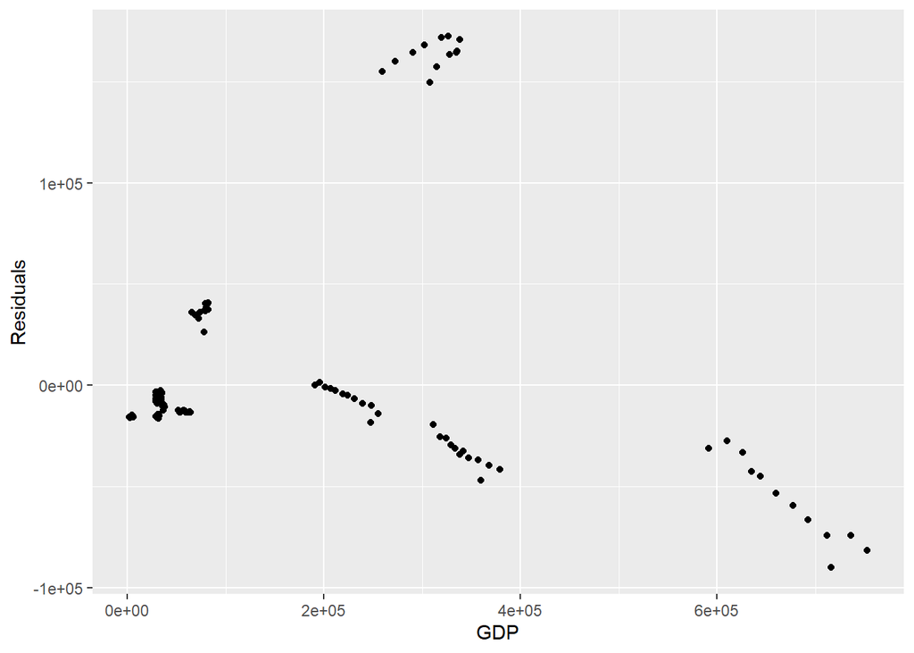

```r
slr_1 <- lm(CO2 ~ gdp, data = CO2_data)

ggplot(data = CO2_data, aes(x = as.numeric(gdp), y = as.numeric(slr_1$residuals))
        )+geom_point()+labs(x = "GDP", y = "Residuals")
```

From this “eyeball test”, it looks like the data display heterskedasticity. We’ll test for this formally now with a Breusch-Pagan test.

```r
CO2_data$resid_sqgdp <-  (slr_1$residuals)^2
residualsslr_1 <- lm(resid_sqgdp ~ gdp, data = CO2_data)
summary(residualsslr_1)
```

```
Call:
lm(formula = resid_sqgdp ~ gdp, data = CO2_data)

Residuals:
       Min         1Q     Median         3Q        Max
-8.419e+09 -1.409e+09 -9.502e+08 -5.301e+08  2.448e+10

Coefficients:
             Estimate Std. Error t value Pr(>|t|)
(Intercept) 742582663  650815713   1.141    0.256
gdp             13820       2747   5.031 1.34e-06 ***
---
Signif. codes:  0 '***' 0.001 '**' 0.01 '*' 0.05 '.' 0.1 ' ' 1

Residual standard error: 6.611e+09 on 154 degrees of freedom
Multiple R-squared:  0.1412,    Adjusted R-squared:  0.1356
F-statistic: 25.31 on 1 and 154 DF,  p-value: 1.343e-06
```

We reject the null hypothesis and conclude that the GDP data are heteroskedastic. Let’s try to address this with a log transformation.

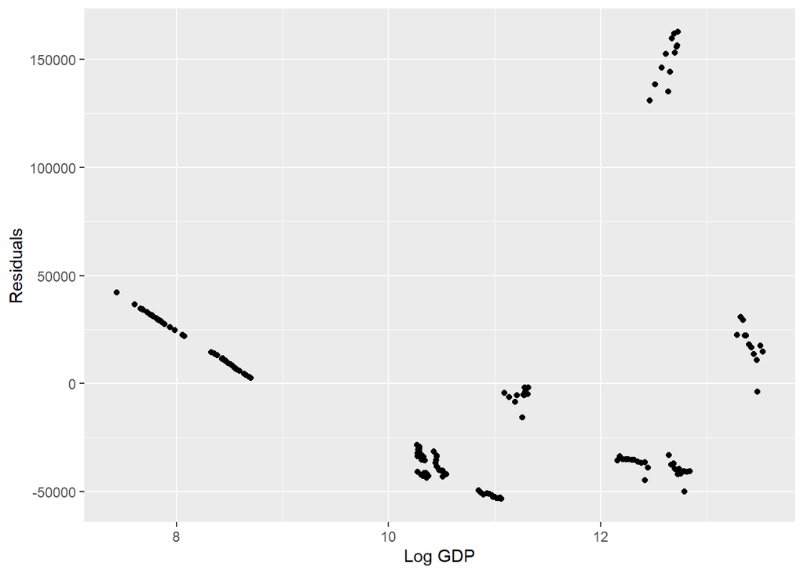

```r
# transform the data
CO2_data <- CO2_data %>%
  mutate(ln_gdp = log(gdp))

# visualize the logged value residuals
slr_ln1 <- lm(CO2 ~ ln_gdp, data = CO2_data)

ggplot(data = CO2_data, aes(x = as.numeric(ln_gdp), y = as.numeric(slr_ln1$residuals))) +
  geom_point()+labs(x = "Log GDP", y = "Residuals")
```

```r
# conduct another Breusch-Pagan Test
CO2_data$resid_sq_lngdp <-  (slr_ln1$residuals)^2
residualsslr_ln1 <- lm(resid_sq_lngdp ~ ln_gdp, data = CO2_data)
summary(residualsslr_ln1)
```

```
Call:
lm(formula = resid_sq_lngdp ~ ln_gdp, data = CO2_data)

Residuals:
       Min         1Q     Median         3Q        Max
-5.921e+09 -3.334e+09 -6.787e+08 -1.289e+08  2.137e+10

Coefficients:
              Estimate Std. Error t value Pr(>|t|)
(Intercept) -8.941e+09  2.537e+09  -3.524 0.000559 ***
ln_gdp       1.103e+09  2.370e+08   4.655 6.93e-06 ***
---
Signif. codes:  0 '***' 0.001 '**' 0.01 '*' 0.05 '.' 0.1 ' ' 1

Residual standard error: 5.501e+09 on 154 degrees of freedom
Multiple R-squared:  0.1234,    Adjusted R-squared:  0.1177
F-statistic: 21.67 on 1 and 154 DF,  p-value: 6.933e-06
```

This doesn’t seem to have fixed the problem of heteroskedasticity within the gdp data. We’ll overcome this in our final model by using robust standard errors. We’ll now go through a similar process with the remaining two variables, and conclude that the electricity data are also heteroskedastic.

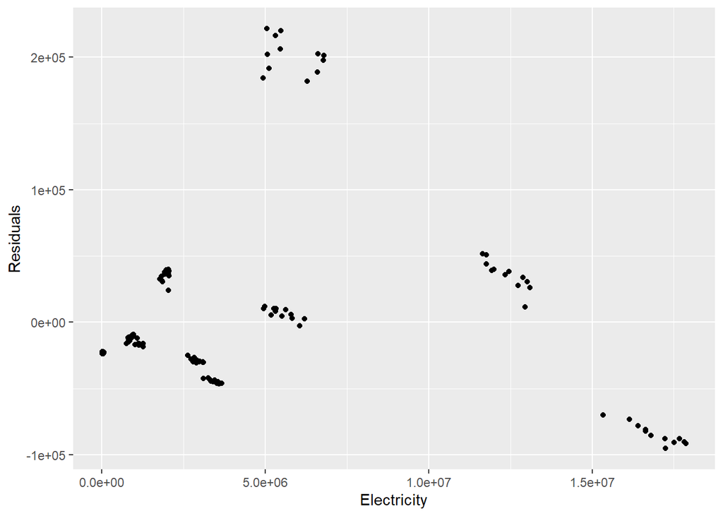

```r
#For `electricity`
#Visualise the residuals
slr_2 <- lm(CO2 ~ electricity, data = CO2_data)
ggplot(data = CO2_data, aes(x = as.numeric(electricity), y = as.numeric(slr_2$residuals))
        )+geom_point()+labs(x = "Electricity", y = "Residuals")
```